# Presentation - BUGS Example

*175904 - Jorge III Altamirano Astorga*

*123972 - Ángel Rafael Ortega Ramírez*

Hepatatis-B (HB) is endemic in Africa. Considering a program in Gambia where we want to test the effectiveness of vaccination. We’d like to know the effectiveness afforded by the vaccination of 106 children, followed up. Each child, or observation is denoted by $i$.

The level of inmunity is measured in *anti-HB titre*. Titre being “the concentration of an antibody, as determined by finding the highest dilution at which it is still able to cause agglutination of the antigen”.

We know, based on a previous study in Senegal (1991) that *anti-HB titre is proportional to the reciprocal of time since vaccination*, and so we work on the basis that the relationship between log-anti-HB-titre and log-time-since-vaccination should be approximately linear.

Let $y_{0i}$ and $y_{ij}$ denote the logbaseline and jth follow-up log-titre measurement: 1, 2 and 3.

Let $t_{ij}$ denote the log-time to which $y_{ij}$ corresponds.

## Model

A non hierarchical model might be:

$$y_{ij} \sim N(\phi_{ij}, \sigma^2), \\
\phi_{ij} = \alpha + \beta(t_{ij} - \overline{t}) + \gamma(y_{0i} - \overline{y_0})$$

Where $\overline{t}$ and $\overline{y_{0}}$ are the empirical means of the $t_{ij}$s and $y_0$s, respectively.

This model might sound a bit unrealistic, as it assumes the same intercept and slope for all individuals.

In a **hierarchical model**, we assume different intercepts and slopes. This model uses captures that all the individuals are related or similar. Using the very same Normal model (non hierarchical) but in a hierarchical fashion would be:

$$y_{ij} \sim N(\phi_{ij}, \sigma^2), \\
\phi_{ij} = \alpha_i + \beta_i (t_{ij} - \overline{t}) + \gamma(y_{0i} - \overline{y_0}),\\
\alpha_i \sim N(\mu_\alpha, \omega^2_\alpha),\\
\beta_i \sim N(\mu_\beta, \omega^2_\beta)$$

All $\mu_\alpha$, $\omega_\alpha$, $\mu_\beta$, and $\omega_\beta$ have been assigned appropriate priors for this mentioned hierarchical model:

$$\mu_\alpha \sim N(0, 0.0001), \\
\omega_\alpha \sim U(0, 100), \\
\mu_\beta \sim N(0, 0.0001), \\
\omega_\beta \sim U(0, 100), \\
log~ \sigma \sim U(-10, 10), \\
\gamma \sim N(0, 0.0001)$$

Data has `NA`s, and those are imputated from their predictive distributions, using the so called *pad out* strategy. This has the benefit of having no impact on the inferences themselves. The trade off is the computation, and, fortunately in this case, the data is balanced. As all observations are 3 observations per child. We explicitly avoid the *bivariate* exchangeability assumption, in this model. This model has *univariate* exchangeability.

### Non-Hierarchical BUGS Model

[output not shown]

### Hierarchical BUGS Model

```
## model {
##   #likelihood
##   for (i in 1:N) {
##     for (j in 1:3) {
##       y[i,j]    ~ dnorm(psi[i,j], inv.sigma.squared)
##       psi[i,j] <- alpha[i] + beta[i]*(t[i,j] - tbar)
##                 + gamma*(y0[i] - y0bar)
##     }
##     alpha[i]    ~ dnorm(mu.alpha, inv.omega.alpha.squared)
##     beta[i]     ~ dnorm(mu.beta, inv.omega.beta.squared)
##   }
##
##   #as bugs uses precision, we do that conversion here
##   inv.sigma.squared <- 1/sigma.squared
##   inv.omega.alpha.squared <- 1/omega.alpha.squared
##   inv.omega.beta.squared <- 1/omega.beta.squared
##
##   #sigma, omega_alpha and omega_beta are squared here
##   sigma.squared <- pow(sigma, 2)
##   omega.alpha.squared <- pow(omega.alpha, 2)
##   omega.beta.squared <- pow(omega.beta, 2)
##
##   #the diffuse uniform distributions are done here, as well the log sigma.
##   log(sigma) <- log.sigma
##   log.sigma ~ dunif(-10, 10)
##   omega.alpha ~ dunif(0, 100)
##   omega.beta ~ dunif(0, 100)
##
##   #mu_alpha, mu_beta and gamma priors are being defined here
##   mu.alpha ~ dnorm(0, 0.0001)
##   mu.beta ~ dnorm(0, 0.0001)
##   gamma ~ dnorm(0, 0.0001)
##
##   #the mean y_0 is being calculated here
##   y0bar <- mean(y0[])
## }
```

## Data

The three follow-ups $j$ per child $i$, in log-titre:

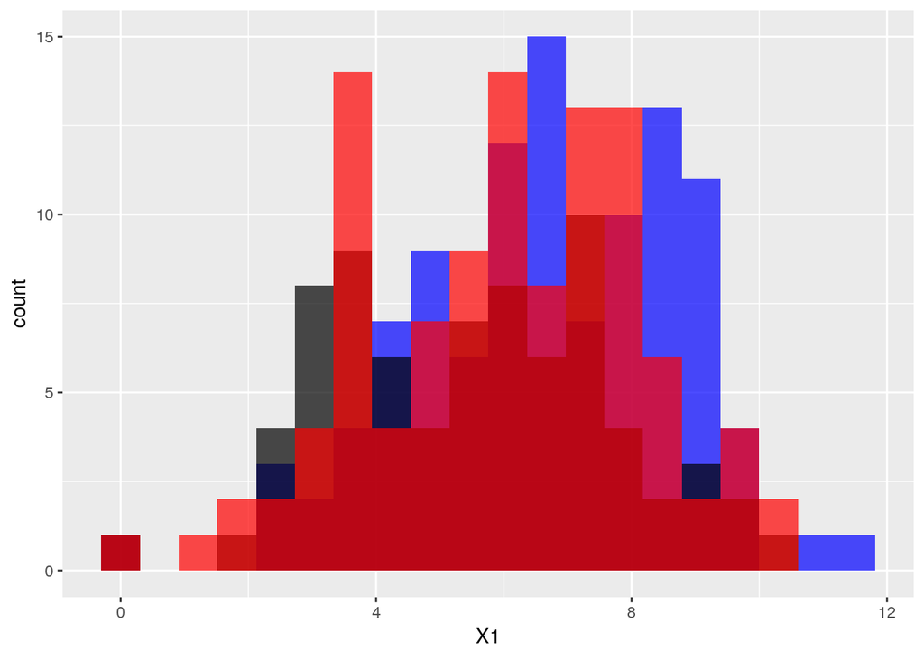

$t$ (log time) is shown here for, different colors represent the 3 observations per child:

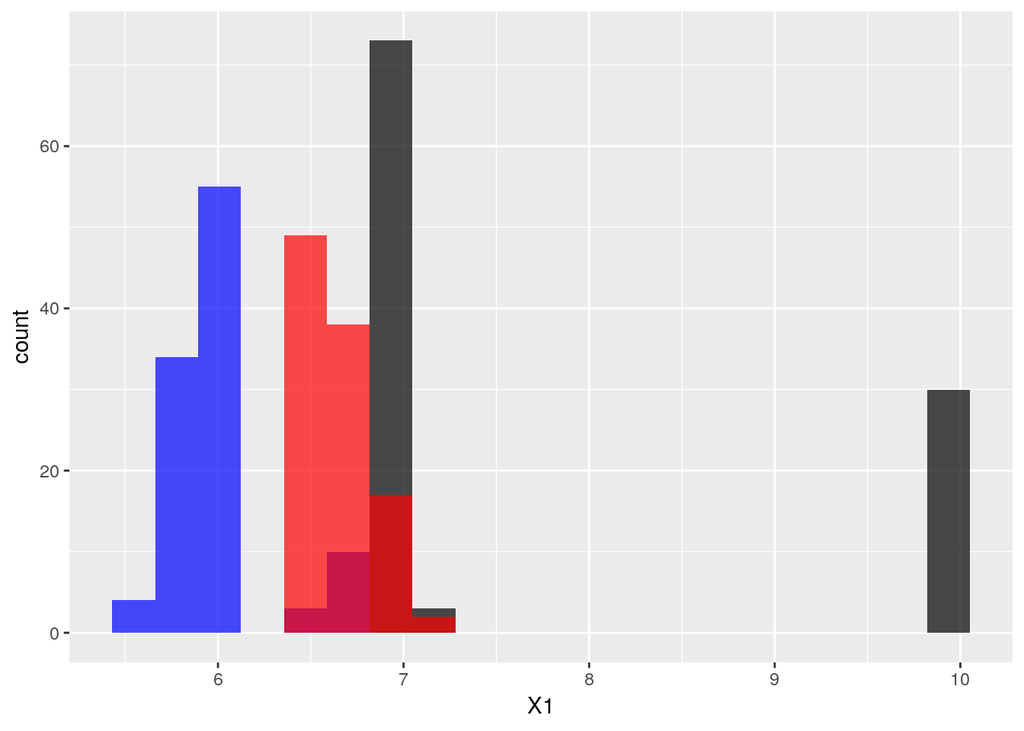

And $y_0$:

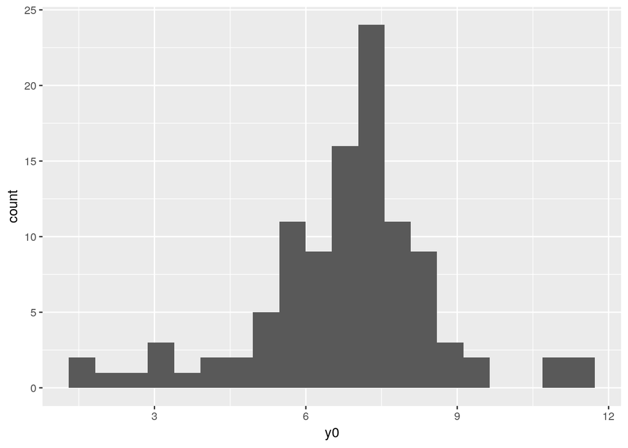

## Non-Hierarchical Model Simulations

```r
#-Defining data-
data <-list("N" = 106, "tbar" = 6.5,
     "y" = y,
     "t" = t,
     "y0" = y0)
#-Defining inits-
inits <- function(){
  list(log.sigma = 0, alpha = 0, beta = 0, gamma = 0)
}

#-Selecting parameters to monitor-
parameters<-c("gamma", "alpha", "beta",
              "sigma.squared")

#-Running code-
#OpenBUGS
simb<-bugs(data,inits,parameters,model.file="expositionb.txt",
              n.iter=5000,n.chains=2,n.burnin=500)
simb
```

```
## Inference for Bugs model at "expositionb.txt",
## Current: 2 chains, each with 5000 iterations (first 500 discarded)
## Cumulative: n.sims = 9000 iterations saved
##                 mean  sd   2.5%    25%    50%    75%  97.5% Rhat n.eff
## gamma            0.7 0.1    0.6    0.6    0.7    0.7    0.8    1  9000
## alpha            6.1 0.1    5.9    6.1    6.1    6.2    6.3    1  4300
## beta            -1.0 0.2   -1.5   -1.2   -1.0   -0.9   -0.6    1  9000
## sigma.squared    3.0 0.3    2.5    2.8    3.0    3.2    3.5    1  2200
## deviance      1132.3 2.9 1129.0 1130.0 1132.0 1134.0 1140.0    1  7000
##
## For each parameter, n.eff is a crude measure of effective sample size,
## and Rhat is the potential scale reduction factor (at convergence, Rhat=1).
##
## DIC info (using the rule, pD = Dbar-Dhat)
## pD = 4.0 and DIC = 1136.0
## DIC is an estimate of expected predictive error (lower deviance is better).
```

### Diagnostic and convergence graphs

Graphs for $\sigma^2$

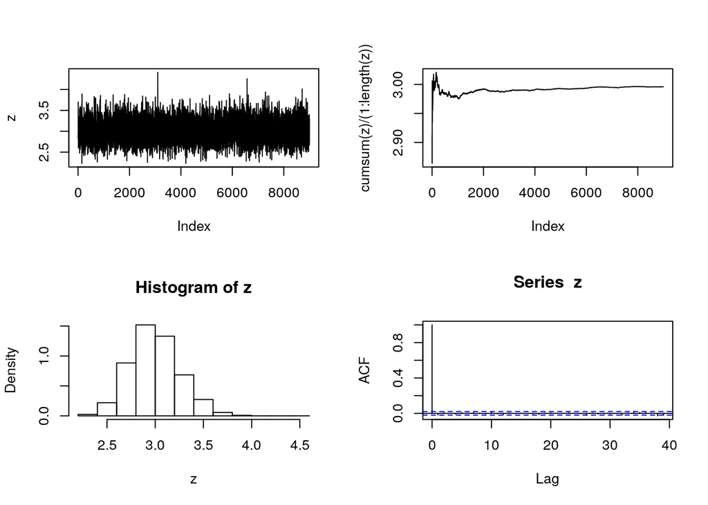

Graphs for $\gamma$

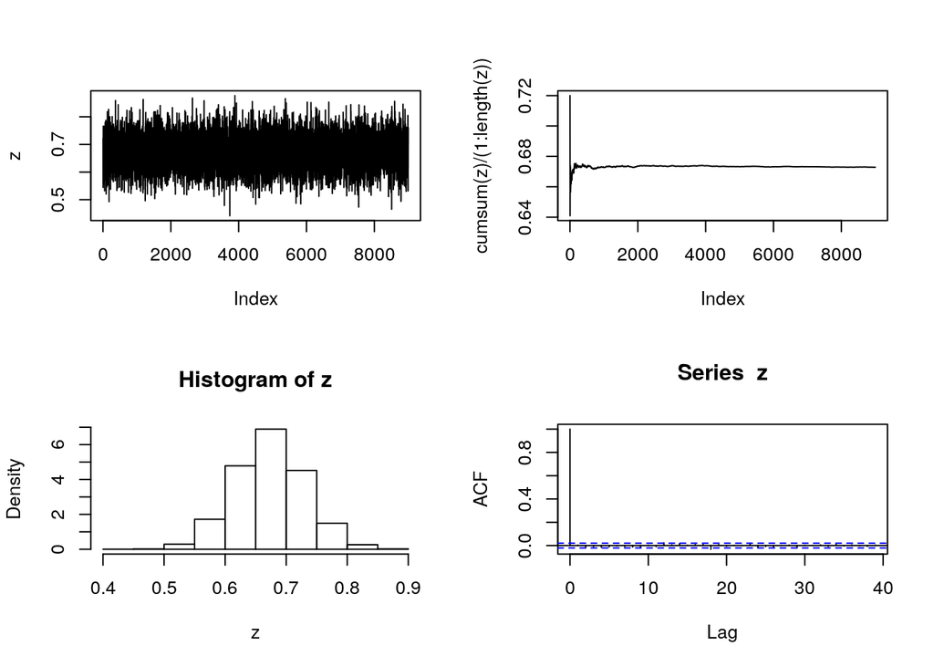

Graphs for $\alpha$

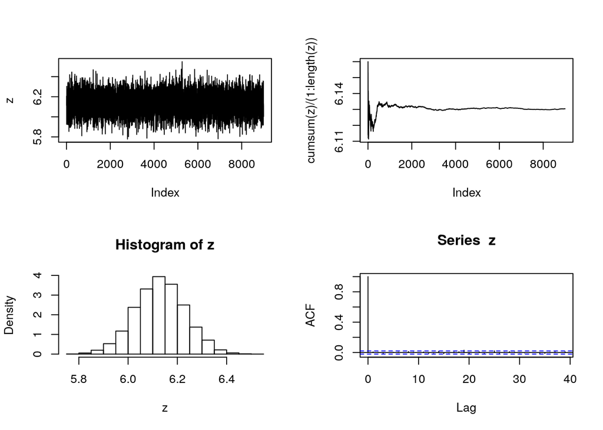

Graphs for $\beta$

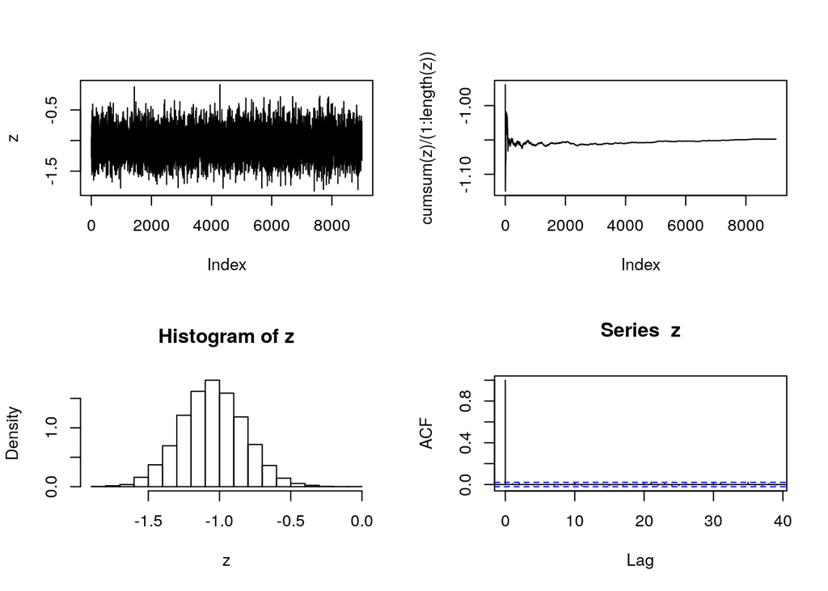

## Hierarchical Model Simulations

```r
#-Defining inits-
inits <- function(){
  list(log.sigma = 0, omega.alpha = 0.1, omega.beta = 0.1,
     mu.alpha = 0, mu.beta = 0, gamma = 0)
}

#-Selecting parameters to monitor-
parameters<-c("gamma","mu.alpha", "mu.beta",
              "omega.alpha.squared",
              "omega.beta.squared",
              "sigma.squared")

#-Running code-
#OpenBUGS
sim<-bugs(data,inits,parameters,model.file="exposition.txt",
              n.iter=5000,n.chains=2,n.burnin=500)
# sim
sim
```

```
## Inference for Bugs model at "exposition.txt",
## Current: 2 chains, each with 5000 iterations (first 500 discarded)
## Cumulative: n.sims = 9000 iterations saved
##                      mean   sd  2.5%   25%   50%   75% 97.5% Rhat n.eff
## gamma                 0.7  0.1   0.5   0.6   0.7   0.7   0.8    1  9000
## mu.alpha              6.1  0.2   5.8   6.0   6.1   6.2   6.4    1  9000
## mu.beta              -1.0  0.1  -1.3  -1.1  -1.0  -1.0  -0.8    1  1400
## omega.alpha.squared   2.1  0.3   1.5   1.8   2.0   2.3   2.8    1  9000
## omega.beta.squared    0.2  0.2   0.0   0.0   0.1   0.3   0.7    1    98
## sigma.squared         1.0  0.1   0.8   0.9   1.0   1.1   1.2    1   580
## deviance            810.6 23.0 762.7 796.1 811.3 825.4 854.5    1   380
##
## For each parameter, n.eff is a crude measure of effective sample size,
## and Rhat is the potential scale reduction factor (at convergence, Rhat=1).
##
## DIC info (using the rule, pD = Dbar-Dhat)
## pD = 100.7 and DIC = 911.3
## DIC is an estimate of expected predictive error (lower deviance is better).
```

### Diagnostic and convergence graphs

Graphs for $\sigma^2$

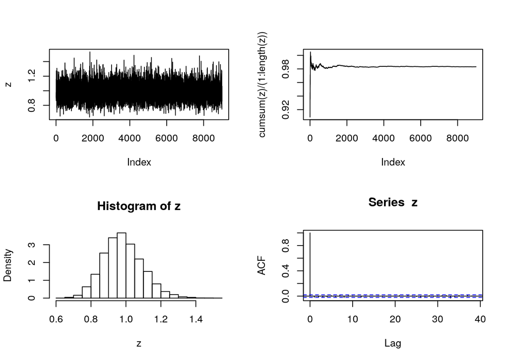

Graphs for $\gamma$

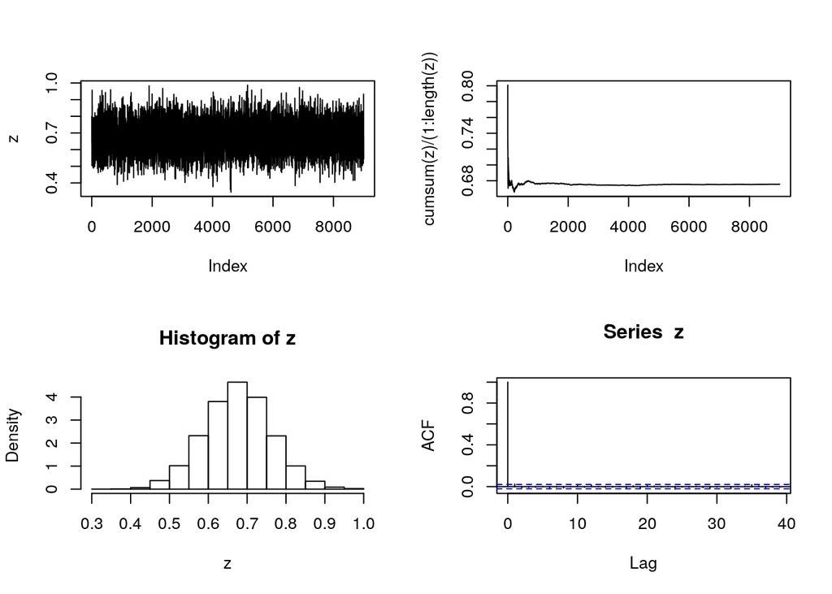

Graphs for $\mu_\alpha$

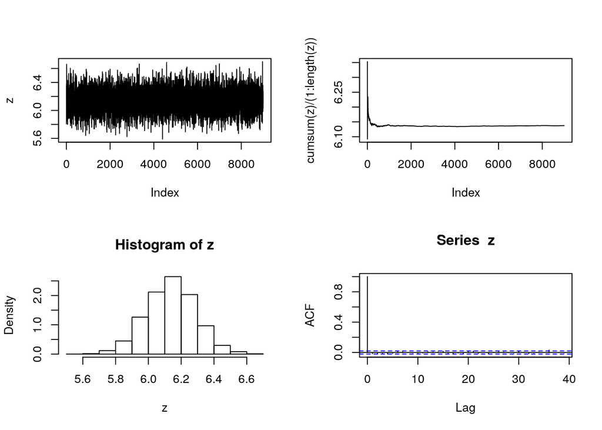

Graphs for $\mu_\beta$

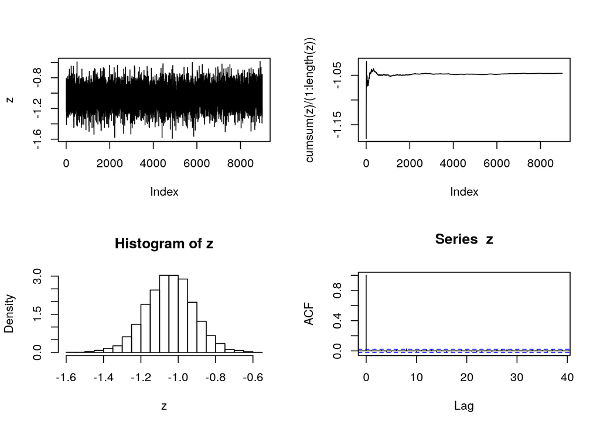

Graphs for $\omega^2_\alpha$

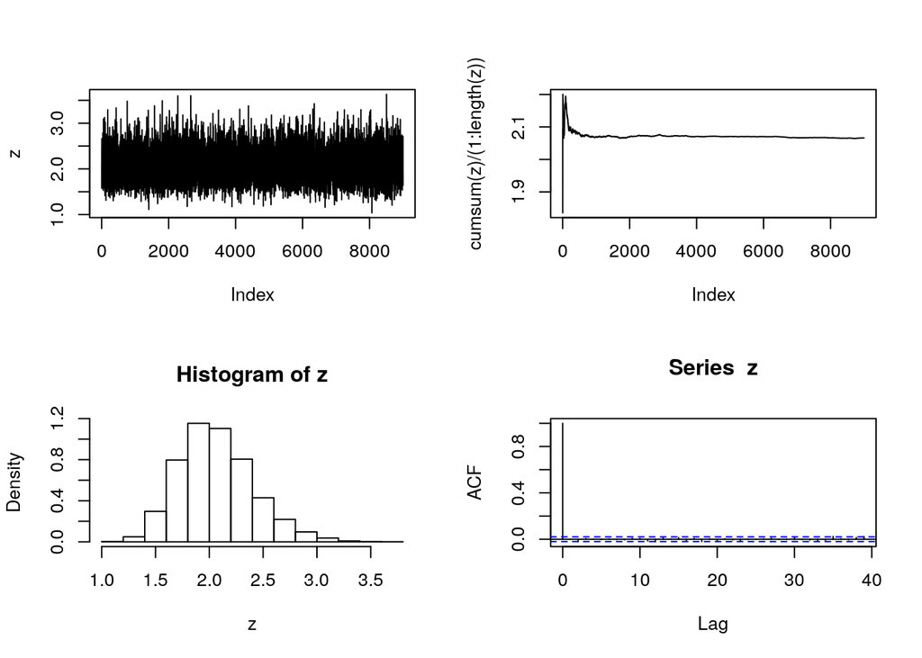

Graphs for $\omega^2_\beta$

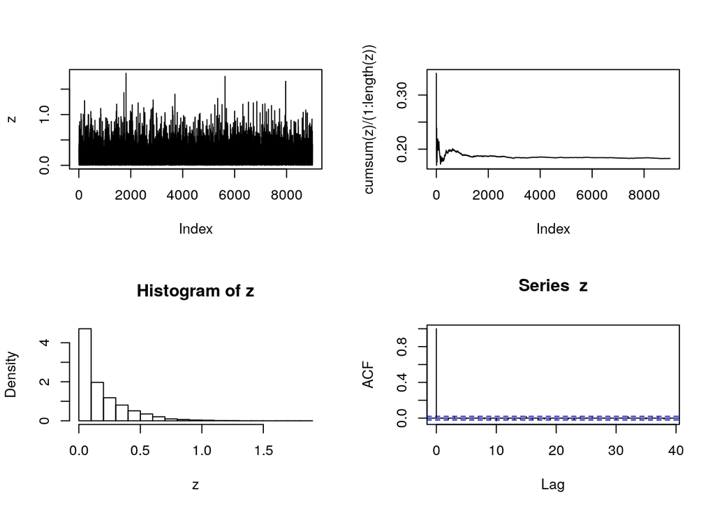

## Comparison & Analisys

Comparison between hierarchical models:

| Hierarchical Model |  |  | Non Hierarchical Model |  |  |
| --- | --- | --- | --- | --- | --- |
| *Parameter* | *95% interval* | *Mean Value* | *Mean Value* | *95% interval* | *Parameter* |
| $\mu_\alpha$ | (5.839, 6.438025) | 6.1374113 | 6.1303957 | (5.930975, 6.328025) | $\alpha$ |
| $\mu_\beta$ | (-1.306025, -0.79219) | -1.0461698 | -1.0487007 | (-1.487, -0.6058) | $\beta$ |
| $\gamma$ | (0.5046975, 0.8464025) | 0.6755986 | 0.6728637 | (0.560895, 0.7842025) | $\gamma$ |
| $\sigma^2$ | (0.7766, 1.221025) | 0.9832054 | 2.9961083 | (2.535975, 3.531) | $\sigma^2$ |
| $\omega^2_\alpha$ | (1.486975, 2.84) | 2.0659314 |  |  |  |
| $\omega^2_\beta$ | (2.61e-03, 0.70603) | 0.1829941 |  |  |  |
| DIC | - | 911.3 | 1136 | - | DIC |

Recalling both models:

- Non Hierarchical

$$y_{ij} \sim N(\phi_{ij}, \sigma^2)\\
\phi_{ij} = \alpha + \beta(t_{ij} - \overline{t}) + \gamma(y_{0i} - \overline{y_0})\\$$

- Hierarchical

$$y_{ij} \sim N(\phi_{ij}, \sigma^2), \\
\phi_{ij} = \alpha_i + \beta_i (t_{ij} - \overline{t}) + \gamma(y_{0i} - \overline{y_0}),\\
\alpha_i \sim N(\mu_\alpha, \omega^2_\alpha),\\
\beta_i \sim N(\mu_\beta, \omega^2_\beta)$$

It is easy to appreciate that both models *capture* the intercept and slope parameters ($\alpha$/$\mu_\alpha$, $\beta$/$\mu_\beta$ for time and $\gamma$ for titre) are similar in both models, largely due to the linear nature of both.

What is noteworth is that the variability is greatly reduced in the hierarchical model, about 1/3. This is suggests that the variability can be reduced by allowing child-specific intercepts.

## References

- Lunn, D., Jackson, C., Best, N., Thomas, A., & Spiegelhalter, D. (2012). The Bugs Book: A Practical Introduction to Bayesian Analysis (1st ed.). Chapter 10.
- Nieto-Barajas, L. (2019). Notas del Curso de Regresión Avanzada.
- Carlin, J., Gelman, A., & Stern, H., et al. (2003). Bayesian data analysis. Chapman and Hall/CRC.
- Goldstein, H. (2011). Multilevel statistical models. Oxford: Wiley.
- Congdon, P. (2010). Applied Bayesian hierarchical methods. Boca Raton: CRC Press.